# Spotify Analysis and Prediction

## Exploratory Data Analysis (EDA)

Exploring our dataset to gain insights into things like our feature distributions, correlations, and relationships that will inform our modeling approach. Some visualizations and summary statistics are included in addition to better understand the data we are working with.

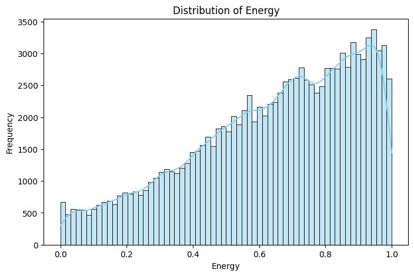

```python
plt.figure(figsize=(8, 5))
sns.histplot(df['energy'], kde=True, color='skyblue')
plt.title('Distribution of Energy')
plt.xlabel('Energy')
plt.ylabel('Frequency')
plt.show()
```

Here we are exploring our **Distribution of Energy**! Our histogram with a KDE (Kernel Density Estimate) overlay is present to show the distribution of our "energy" variable well.

Overall, our plot is showing a clear exploration of our target variable's distribution.

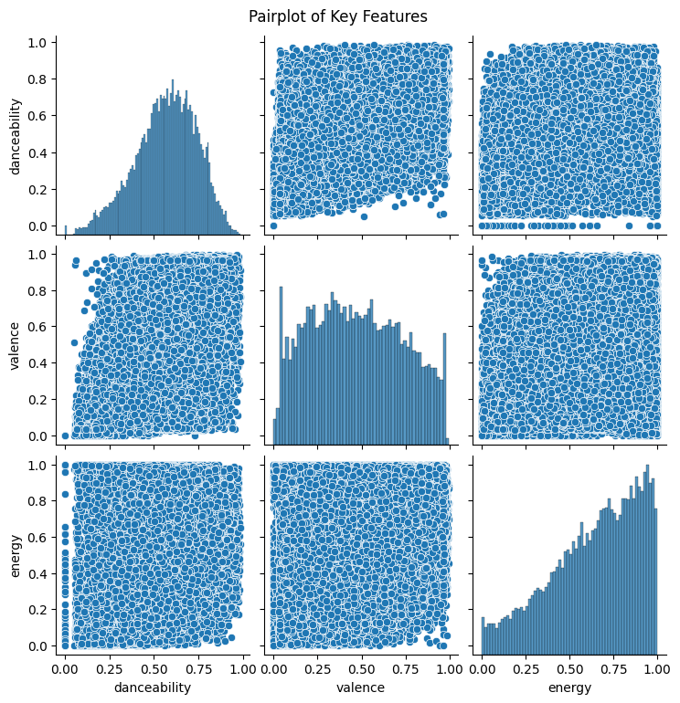

```python
sns.pairplot(df, vars=['danceability', 'valence', 'energy'])
plt.suptitle('Pairplot of Key Features', y=1.02)
plt.show()
```

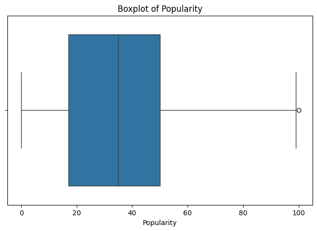

```python
plt.figure(figsize=(8, 5))
sns.boxplot(x=df['popularity'])
plt.title('Boxplot of Popularity')
plt.xlabel('Popularity')
plt.show()
```

## Ps. Personal Inspiration!

This project was made with alot of love, as it combines my deep passion for both **music** and **data science**. Spotify has always inspired me, not only as a platform for discovering music but also as a company pioneering innovation and features in the audio streaming industry. I have lived my entire life creating different playlists for different times and experiences in my life. It is my dream to work as a "Data Alchemist" for Spotify, where I can merge my love for music with data-driven insights to create meaningful experiences for listeners worldwide!!

Throughout this project, I was motivated by Spotify’s data-rich environment and its endless potential I feel that they have in this age, to unlock powerful insights about music and user preferences. I think it's pretty awesome. All to say that I am inspired by the company's continuous advancements in music recommendation and personalization, and I aspire to contribute to these projects one day. :)

Now, our **Boxplot of Popularity** is shown to provide a clear visualization of the distribution of the "popularity" feature (another feature I was considering to be my target variable).

```python
df[df.isnull().any(axis=1)]
```

|  | track_id | artists | album_name | track_name | popularity | duration_ms | explicit | danceability | energy | key | loudness | mode | speechiness | acousticness | instrumentalness | liveness | valence | tempo | time_signature | track_genre |
| --- | --- | --- | --- | --- | --- | --- | --- | --- | --- | --- | --- | --- | --- | --- | --- | --- | --- | --- | --- | --- |
| 65900 | 1kR4gIb7nGxHPI3D2ifs59 | NaN | NaN | NaN | 0 | 0 | False | 0.501 | 0.583 | 7 | -9.46 | 0 | 0.0605 | 0.69 | 0.00396 | 0.0747 | 0.734 | 138.391 | 4 | k-pop |

```python
df.head(10)
```

|  | track_id | artists | album_name | track_name | popularity | duration_ms | explicit | danceability | energy | key | loudness | mode | speechiness | acousticness | instrumentalness | liveness | valence | tempo | time_signature | track_genre |
| --- | --- | --- | --- | --- | --- | --- | --- | --- | --- | --- | --- | --- | --- | --- | --- | --- | --- | --- | --- | --- |
| 0 | 5SuOikwiRyPMVoIQDJUgSV | Gen Hoshino | Comedy | Comedy | 73 | 230666 | False | 0.676 | 0.4610 | 1 | -6.746 | 0 | 0.1430 | 0.0322 | 0.000001 | 0.3580 | 0.7150 | 87.917 | 4 | acoustic |
| 1 | 4qPNDBW1i3p13qLCt0Ki3A | Ben Woodward | Ghost (Acoustic) | Ghost - Acoustic | 55 | 149610 | False | 0.420 | 0.1660 | 1 | -17.235 | 1 | 0.0763 | 0.9240 | 0.000006 | 0.1010 | 0.2670 | 77.489 | 4 | acoustic |
| 2 | 1iJBSr7s7jYXzM8EGcbK5b | Ingrid Michaelson;ZAYN | To Begin Again | To Begin Again | 57 | 210826 | False | 0.438 | 0.3590 | 0 | -9.734 | 1 | 0.0557 | 0.2100 | 0.000000 | 0.1170 | 0.1200 | 76.332 | 4 | acoustic |
| 3 | 6lfxq3CG4xtTiEg7opyCyx | Kina Grannis | Crazy Rich Asians (Original Motion Picture Sou... | Can't Help Falling In Love | 71 | 201933 | False | 0.266 | 0.0596 | 0 | -18.515 | 1 | 0.0363 | 0.9050 | 0.000071 | 0.1320 | 0.1430 | 181.740 | 3 | acoustic |
| 4 | 5vjLSffimiIP26QG5WcN2K | Chord Overstreet | Hold On | Hold On | 82 | 198853 | False | 0.618 | 0.4430 | 2 | -9.681 | 1 | 0.0526 | 0.4690 | 0.000000 | 0.0829 | 0.1670 | 119.949 | 4 | acoustic |
| 5 | 01MVOl9KtVTNfFiBU9I7dc | Tyrone Wells | Days I Will Remember | Days I Will Remember | 58 | 214240 | False | 0.688 | 0.4810 | 6 | -8.807 | 1 | 0.1050 | 0.2890 | 0.000000 | 0.1890 | 0.6660 | 98.017 | 4 | acoustic |
| 6 | 6Vc5wAMmXdKIAM7WUoEb7N | A Great Big World;Christina Aguilera | Is There Anybody Out There? | Say Something | 74 | 229400 | False | 0.407 | 0.1470 | 2 | -8.822 | 1 | 0.0355 | 0.8570 | 0.000003 | 0.0913 | 0.0765 | 141.284 | 3 | acoustic |
| 7 | 1EzrEOXmMH3G43AXT1y7pA | Jason Mraz | We Sing. We Dance. We Steal Things. | I'm Yours | 80 | 242946 | False | 0.703 | 0.4440 | 11 | -9.331 | 1 | 0.0417 | 0.5590 | 0.000000 | 0.0973 | 0.7120 | 150.960 | 4 | acoustic |
| 8 | 0IktbUcnAGrvD03AWnz3Q8 | Jason Mraz;Colbie Caillat | We Sing. We Dance. We Steal Things. | Lucky | 74 | 189613 | False | 0.625 | 0.4140 | 0 | -8.700 | 1 | 0.0369 | 0.2940 | 0.000000 | 0.1510 | 0.6690 | 130.088 | 4 | acoustic |
| 9 | 7k9GuJYLp2AzqokyEdwEw2 | Ross Copperman | Hunger | Hunger | 56 | 205594 | False | 0.442 | 0.6320 | 1 | -6.770 | 1 | 0.0295 | 0.4260 | 0.004190 | 0.0735 | 0.1960 | 78.899 | 4 | acoustic |

## Objective and Data Description

### Research Objective

The primary objective of this project is to build a predictive model to estimate the **energy** of a song based on its audio features. Energy is quite of a perceptual measure of intensity and activity in music, with high-energy tracks often being fast-paced, loud, and intense. Understanding and predicting energy levels can be valuable for applications in music recommendation, playlist curation, and enhancing user experience on music platforms.

### Research Questions

- **What audio features most strongly correlate with the energy level of a track?** By exploring feature relationships, we are really aiming to identify key factors that influence a song’s intensity.
- **How do different activation functions affect the model's ability to accurately predict energy?** We compare the effectiveness of Sigmoid, Tanh, and ReLU activation functions in predicting energy.
- **What impact do various batch sizes have on model performance?** Exploring different batch sizes allows us to determine optimal training dynamics for predicting energy accurately as you will see in the progression of this study.

## Data Preprocessing

Covering data preprocessing steps, including handling missing values, normalizing numerical features, and encoding categorical variables to prepare the data for modeling.

```python
# here we are now dropping rows with missing values in specific columns
df_cleaned = df.dropna(subset=['artists', 'album_name', 'track_name'])

# then we confirm the number of rows to ensure the drop was successful
df_cleaned.info()
```

```
<class 'pandas.core.frame.DataFrame'>
Index: 113999 entries, 0 to 113999
Data columns (total 20 columns):
 #   Column            Non-Null Count   Dtype
---  ------            --------------   -----
 0   track_id          113999 non-null  object
 1   artists           113999 non-null  object
 2   album_name        113999 non-null  object
 3   track_name        113999 non-null  object
 4   popularity        113999 non-null  int64
 5   duration_ms       113999 non-null  int64
 6   explicit          113999 non-null  bool
 7   danceability      113999 non-null  float64
 8   energy            113999 non-null  float64
 9   key               113999 non-null  int64
 10  loudness          113999 non-null  float64
 11  mode              113999 non-null  int64
 12  speechiness       113999 non-null  float64
 13  acousticness      113999 non-null  float64
 14  instrumentalness  113999 non-null  float64
 15  liveness          113999 non-null  float64
 16  valence           113999 non-null  float64
 17  tempo             113999 non-null  float64
 18  time_signature    113999 non-null  int64
 19  track_genre       113999 non-null  object
dtypes: bool(1), float64(9), int64(5), object(5)
memory usage: 17.5+ MB
```

```python
scaler = MinMaxScaler()

numerical_cols = ['popularity', 'duration_ms', 'danceability', 'energy',
                  'loudness', 'speechiness', 'acousticness', 'instrumentalness',
                  'liveness', 'valence', 'tempo']
```

```python
df_cleaned[numerical_cols] = scaler.fit_transform(df_cleaned[numerical_cols])
df_cleaned[numerical_cols].describe()
```

|  | popularity | duration_ms | danceability | energy | loudness | speechiness | acousticness | instrumentalness | liveness | valence | tempo |
| --- | --- | --- | --- | --- | --- | --- | --- | --- | --- | --- | --- |
| count | 113999.000000 | 113999.000000 | 113999.000000 | 113999.000000 | 113999.000000 | 113999.000000 | 113999.000000 | 113999.000000 | 113999.000000 | 113999.000000 | 113999.000000 |
| mean | 0.332388 | 0.041969 | 0.575432 | 0.641383 | 0.763407 | 0.087723 | 0.316171 | 0.156051 | 0.213554 | 0.476448 | 0.501897 |
| std | 0.223050 | 0.020521 | 0.176186 | 0.251530 | 0.093028 | 0.109568 | 0.333858 | 0.309556 | 0.190378 | 0.260564 | 0.123179 |
| min | 0.000000 | 0.000000 | 0.000000 | 0.000000 | 0.000000 | 0.000000 | 0.000000 | 0.000000 | 0.000000 | 0.000000 | 0.000000 |
| 25% | 0.170000 | 0.031648 | 0.462944 | 0.472000 | 0.730962 | 0.037202 | 0.016968 | 0.000000 | 0.098000 | 0.261307 | 0.407682 |
| 50% | 0.350000 | 0.039077 | 0.588832 | 0.685000 | 0.786619 | 0.050674 | 0.169679 | 0.000042 | 0.132000 | 0.466332 | 0.501360 |
| 75% | 0.500000 | 0.048371 | 0.705584 | 0.854000 | 0.823632 | 0.087565 | 0.599900 | 0.049000 | 0.273000 | 0.686432 | 0.575543 |
| max | 1.000000 | 1.000000 | 1.000000 | 1.000000 | 1.000000 | 1.000000 | 1.000000 | 1.000000 | 1.000000 | 1.000000 | 1.000000 |

```python
# one-hot encoding 'track_genre'
df_cleaned = pd.get_dummies(df_cleaned, columns=['track_genre'], prefix='genre')
```

```python
# then we display first few rows to double check our encoding
df_cleaned.head()
```

[output not shown]

```python
from sklearn.model_selection import train_test_split

# defining features (X) and target (y)
X = df_cleaned.drop(columns=['energy'])  # Replace 'energy' with your target column if different
y = df_cleaned['energy']

# splitting dataset into training and testing sets (80% train, 20% test)
X_train, X_test, y_train, y_test = train_test_split(X, y, test_size=0.2, random_state=42)

# then we confirm shape of the resulting splits
X_train.shape, X_test.shape, y_train.shape, y_test.shape
```

[output not shown]

```python
# pip install torch
```

```python
import torch
import torch.nn as nn
import torch.optim as optim
from torch.utils.data import DataLoader, TensorDataset
```

```python
# identify non-numeric columns in X_train
non_numeric_cols = X_train.select_dtypes(include=['object']).columns
print("Non-numeric columns:", non_numeric_cols)
```

```
Non-numeric columns: Index(['track_id', 'artists', 'album_name', 'track_name'], dtype='object')
```

```python
# dropping non-numeric columns that aren't needed for our model
X_train = X_train.drop(columns=['track_id', 'artists', 'album_name', 'track_name'])
X_test = X_test.drop(columns=['track_id', 'artists', 'album_name', 'track_name'])

# confirming again that all columns are now numeric
print(X_train.dtypes)
```

[output not shown]

```python
# convert boolean columns to integers (0 and 1)
X_train = X_train.astype({col: 'int' for col in X_train.select_dtypes(include='bool').columns})
X_test = X_test.astype({col: 'int' for col in X_test.select_dtypes(include='bool').columns})

# again confirming all columns are now numeric
print(X_train.dtypes)
```

```
popularity           float64
duration_ms          float64
explicit               int64
danceability         float64
key                    int64
                      ...
genre_techno           int64
genre_trance           int64
genre_trip-hop         int64
genre_turkish          int64
genre_world-music      int64
Length: 128, dtype: object
```

## Model Design

We are now outlining some of the architecture of our neural net, including number of layers, activation functions, and the design rationale!

```python
# converting our data to PyTorch tensors
X_train_tensor = torch.tensor(X_train.values, dtype=torch.float32)
y_train_tensor = torch.tensor(y_train.values, dtype=torch.float32)
X_test_tensor = torch.tensor(X_test.values, dtype=torch.float32)
y_test_tensor = torch.tensor(y_test.values, dtype=torch.float32)
```

```python
# then we are to create a DataLoader for the batch processing
train_dataset = TensorDataset(X_train_tensor, y_train_tensor)
train_loader = DataLoader(train_dataset, batch_size=64, shuffle=True)
```

```python
# defining our neural net model at last!
class EnergyNet(nn.Module):
    def __init__(self):
        super(EnergyNet, self).__init__()
        self.fc1 = nn.Linear(128, 64)      # input layer to first hidden layer
        self.fc2 = nn.Linear(64, 32)       # 1st hidden layer to second hidden layer
        self.fc3 = nn.Linear(32, 16)       # 2nd hidden layer to third hidden layer
        self.output = nn.Linear(16, 1)     # 3rd hidden layer to output layer

    def forward(self, x):
        x = torch.relu(self.fc1(x))       # we are using ReLU as our default activation
        x = torch.relu(self.fc2(x))
        x = torch.relu(self.fc3(x))
        x = self.output(x)                # then we are to do linear activation for regression
        return x
```

```python
# instantiating our model, define the loss function and the optimizer
model = EnergyNet()
criterion = nn.MSELoss()
optimizer = optim.SGD(model.parameters(), lr=0.01)

# training loop
num_epochs = 50  # we set this based on our personal desired training duration and performance
```

```python
for epoch in range(num_epochs):
    model.train()
    running_loss = 0.0
    for X_batch, y_batch in train_loader:
        optimizer.zero_grad()              # 0 the gradients
        outputs = model(X_batch).squeeze() # forward pass
        loss = criterion(outputs, y_batch) # compute loss
        loss.backward()                    # backward pass
        optimizer.step()                   # updating weights
        running_loss += loss.item()

    print(f"Epoch [{epoch+1}/{num_epochs}], Loss: {running_loss/len(train_loader):.4f}")
```

```
Epoch [1/50], Loss: 0.0588
Epoch [2/50], Loss: 0.0286
Epoch [3/50], Loss: 0.0218
Epoch [4/50], Loss: 0.0198
Epoch [5/50], Loss: 0.0183
Epoch [6/50], Loss: 0.0172
Epoch [7/50], Loss: 0.0163
Epoch [8/50], Loss: 0.0155
Epoch [9/50], Loss: 0.0150
Epoch [10/50], Loss: 0.0146
Epoch [11/50], Loss: 0.0142
Epoch [12/50], Loss: 0.0139
Epoch [13/50], Loss: 0.0138
Epoch [14/50], Loss: 0.0136
Epoch [15/50], Loss: 0.0135
Epoch [16/50], Loss: 0.0135
Epoch [17/50], Loss: 0.0133
Epoch [18/50], Loss: 0.0133
Epoch [19/50], Loss: 0.0131
Epoch [20/50], Loss: 0.0131
Epoch [21/50], Loss: 0.0130
Epoch [22/50], Loss: 0.0129
Epoch [23/50], Loss: 0.0128
Epoch [24/50], Loss: 0.0128
Epoch [25/50], Loss: 0.0128
Epoch [26/50], Loss: 0.0128
Epoch [27/50], Loss: 0.0127
Epoch [28/50], Loss: 0.0127
Epoch [29/50], Loss: 0.0126
Epoch [30/50], Loss: 0.0126
Epoch [31/50], Loss: 0.0125
Epoch [32/50], Loss: 0.0125
Epoch [33/50], Loss: 0.0125
Epoch [34/50], Loss: 0.0124
Epoch [35/50], Loss: 0.0124
Epoch [36/50], Loss: 0.0124
Epoch [37/50], Loss: 0.0124
Epoch [38/50], Loss: 0.0123
Epoch [39/50], Loss: 0.0123
Epoch [40/50], Loss: 0.0124
Epoch [41/50], Loss: 0.0123
Epoch [42/50], Loss: 0.0123
Epoch [43/50], Loss: 0.0122
Epoch [44/50], Loss: 0.0122
Epoch [45/50], Loss: 0.0122
Epoch [46/50], Loss: 0.0122
Epoch [47/50], Loss: 0.0122
Epoch [48/50], Loss: 0.0122
Epoch [49/50], Loss: 0.0122
Epoch [50/50], Loss: 0.0121
```

```python
# our model eval on test data
model.eval()
with torch.no_grad():
    test_predictions = model(X_test_tensor).squeeze()
    test_loss = criterion(test_predictions, y_test_tensor)
    print(f"Test Loss: {test_loss.item():.4f}")
```

```
Test Loss: 0.0122
```

## Activation Functions

Now we are exploring the use of different activation functions (Sigmoid, Tanh, and ReLU) in our neural network. We compare the effects of each activation function on model performance to determine the most effective configuration!

```python
class EnergyNetReLU(nn.Module):
    def __init__(self):
        super(EnergyNetReLU, self).__init__()
        self.fc1 = nn.Linear(128, 64)
        self.fc2 = nn.Linear(64, 32)
        self.fc3 = nn.Linear(32, 16)
        self.output = nn.Linear(16, 1)

    def forward(self, x):
        x = torch.relu(self.fc1(x))
        x = torch.relu(self.fc2(x))
        x = torch.relu(self.fc3(x))
        x = self.output(x)
        return x
```

```python
print("Training with ReLU activation:")
relu_model = EnergyNetReLU()
relu_loss = train_and_evaluate_model(relu_model, X_train_tensor, y_train_tensor, X_test_tensor, y_test_tensor)
```

```
Training with ReLU activation:
Epoch [10/50], Loss: 0.0154
Epoch [20/50], Loss: 0.0134
Epoch [30/50], Loss: 0.0125
Epoch [40/50], Loss: 0.0121
Epoch [50/50], Loss: 0.0119
Test Loss: 0.0116
```

```python
class EnergyNetSigmoid(nn.Module):
    def __init__(self):
        super(EnergyNetSigmoid, self).__init__()
        self.fc1 = nn.Linear(128, 64)
        self.fc2 = nn.Linear(64, 32)
        self.fc3 = nn.Linear(32, 16)
        self.output = nn.Linear(16, 1)

    def forward(self, x):
        x = torch.sigmoid(self.fc1(x))
        x = torch.sigmoid(self.fc2(x))
        x = torch.sigmoid(self.fc3(x))
        x = self.output(x)
        return x
```

```python
print("\nTraining with Sigmoid activation:")
sigmoid_model = EnergyNetSigmoid()
sigmoid_loss = train_and_evaluate_model(sigmoid_model, X_train_tensor, y_train_tensor, X_test_tensor, y_test_tensor)
```

```
Training with Sigmoid activation:
Epoch [10/50], Loss: 0.0634
Epoch [20/50], Loss: 0.0633
Epoch [30/50], Loss: 0.0632
Epoch [40/50], Loss: 0.0631
Epoch [50/50], Loss: 0.0628
Test Loss: 0.0629
```

```python
class EnergyNetTanh(nn.Module):
    def __init__(self):
        super(EnergyNetTanh, self).__init__()
        self.fc1 = nn.Linear(128, 64)
        self.fc2 = nn.Linear(64, 32)
        self.fc3 = nn.Linear(32, 16)
        self.output = nn.Linear(16, 1)

    def forward(self, x):
        x = torch.tanh(self.fc1(x))
        x = torch.tanh(self.fc2(x))
        x = torch.tanh(self.fc3(x))
        x = self.output(x)
        return x
```

```python
print("\nTraining with Tanh activation:")
tanh_model = EnergyNetTanh()
tanh_loss = train_and_evaluate_model(tanh_model, X_train_tensor, y_train_tensor, X_test_tensor, y_test_tensor)
```

```
Training with Tanh activation:
Epoch [10/50], Loss: 0.0144
Epoch [20/50], Loss: 0.0135
Epoch [30/50], Loss: 0.0133
Epoch [40/50], Loss: 0.0131
Epoch [50/50], Loss: 0.0129
Test Loss: 0.0136
```

```python
def train_and_evaluate_model(model, X_train_tensor, y_train_tensor, X_test_tensor, y_test_tensor, num_epochs=50, learning_rate=0.01):
    # initializing our loss function and optimizer
    criterion = nn.MSELoss()
    optimizer = optim.SGD(model.parameters(), lr=learning_rate)

    # DataLoader for training
    train_dataset = TensorDataset(X_train_tensor, y_train_tensor)
    train_loader = DataLoader(train_dataset, batch_size=64, shuffle=True)

    # here is our training loop
    for epoch in range(num_epochs):
        model.train()
        running_loss = 0.0
        for X_batch, y_batch in train_loader:
            optimizer.zero_grad()
            outputs = model(X_batch).squeeze()
            loss = criterion(outputs, y_batch)
            loss.backward()
            optimizer.step()
            running_loss += loss.item()

        if (epoch + 1) % 10 == 0:
            print(f"Epoch [{epoch+1}/{num_epochs}], Loss: {running_loss/len(train_loader):.4f}")

    model.eval()
    with torch.no_grad():
        test_predictions = model(X_test_tensor).squeeze()
        test_loss = criterion(test_predictions, y_test_tensor)
        print(f"Test Loss: {test_loss.item():.4f}")
    return test_loss.item()
```

```python
activation_comparison = pd.DataFrame({
    'Activation Function': ['ReLU', 'Sigmoid', 'Tanh'],
    'Final Training Loss': [0.0119, 0.0628, 0.0129],
    'Test Loss': [0.0116, 0.0629, 0.0136]
})

print(activation_comparison)
```

```
  Activation Function  Final Training Loss  Test Loss
0                ReLU               0.0119     0.0116
1             Sigmoid               0.0628     0.0629
2                Tanh               0.0129     0.0136
```

```python
# pip install tabulate
```

```python
from IPython.display import Markdown, display

activation_comparison = pd.DataFrame({
    'Activation Function': ['ReLU', 'Sigmoid', 'Tanh'],
    'Final Training Loss': [0.0119, 0.0628, 0.0129],
    'Test Loss': [0.0116, 0.0629, 0.0136]
})

def display_table(df):
    table_str = df.to_markdown(index=False)
    display(Markdown(table_str))

display_table(activation_comparison)
```

| Activation Function | Final Training Loss | Test Loss |
| --- | --- | --- |
| ReLU | 0.0119 | 0.0116 |
| Sigmoid | 0.0628 | 0.0629 |
| Tanh | 0.0129 | 0.0136 |

```python
activation_summary = pd.DataFrame({
    'Activation Function': ['ReLU', 'Sigmoid', 'Tanh'],
    'Final Training Loss': [0.0119, 0.0628, 0.0129],
    'Test Loss': [0.0116, 0.0629, 0.0136],
    'Observations': [
        "ReLU performed best overall, achieving the lowest test loss and converging to a low training loss. This aligns with the fact that ReLU generally works well for hidden layers in neural networks.",
        "Sigmoid struggled to reduce the loss, resulting in the highest final test loss among the three activation functions. This could be due to the vanishing gradient problem, where gradients diminish in deeper layers, slowing learning.",
        "Tanh performed better than Sigmoid but didn’t reach the performance of ReLU. This is expected, as Tanh can also suffer from vanishing gradients, though it’s generally better than Sigmoid in this regard."
    ]
})

def display_table(df):
    table_str = df.to_markdown(index=False)
    display(Markdown(table_str))

display_table(activation_summary)
```

| Activation Function | Final Training Loss | Test Loss | Observations |
| --- | --- | --- | --- |
| ReLU | 0.0119 | 0.0116 | ReLU performed best overall, achieving the lowest test loss and converging to a low training loss. This aligns with the fact that ReLU generally works well for hidden layers in neural networks. |
| Sigmoid | 0.0628 | 0.0629 | Sigmoid struggled to reduce the loss, resulting in the highest final test loss among the three activation functions. This could be due to the vanishing gradient problem, where gradients diminish in de… |
| Tanh | 0.0129 | 0.0136 | Tanh performed better than Sigmoid but didn’t reach the performance of ReLU. This is expected, as Tanh can also suffer from vanishing gradients, though it’s generally better than Sigmoid in this regar… |